# PS1 Solution

Statistics and Econometrics

Qian Zhang

4 November 2020

## Question 1

### 1.

It is possible that when the class size is smaller, the test score is higher because the teacher could focus more on each student in the classroom.

### 2.

It does not necessarily indicate that smaller class sizes cause better performance, unless we could consider other factors. For example, the tuition for the smaller class size might be higher, so parants who could afford the tuition might appreciate the test score of their children more than the parents who could not afford the tuition, thus the children of the former might have higher standardized test score than the children of the later do, but it does not imply the direct relationship between smaller class sizes and better performance.

## Question 2

```r
load("fertil2.RData")
library(stargazer)
library(dplyr)
```

```r
library(ggplot2)
```

### 1.

```r
cat("Smallest value of children: ",min(data[, "children"],na.rm=TRUE))
```

```
## Smallest value of children:  0
```

```r
cat("Largest value of children: ",max(data[, "children"],na.rm=TRUE))
```

```
## Largest value of children:  13
```

```r
cat("Average value of children: ",mean(data[, "children"],na.rm=TRUE))
```

```
## Average value of children:  2.267828
```

### 2.

```r
cat("Average of husbands years of education: ", mean(data[,"heduc"],na.rm=TRUE))
```

```
## Average of husbands years of education:  5.144683
```

The number of observation used to compute this average is the length of heduc after all NULL entities are removed.

```r
cat("Number of observation: ", length(which(!is.na(data['heduc']))))
```

```
## Number of observation:  1956
```

### 3.

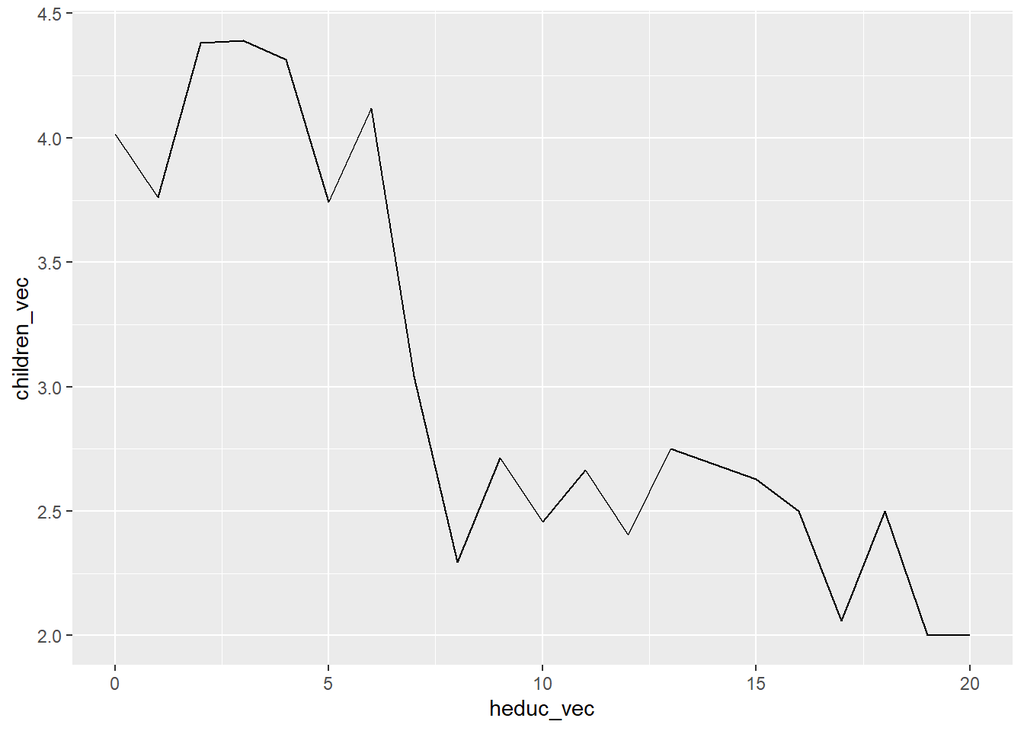

```r
min_heduc <- min(data["heduc"],na.rm=TRUE)
max_heduc <- max(data["heduc"],na.rm=TRUE)
children <- data["children"]
new_data <- data[!is.na(data$heduc),]
heduc_vec <- min_heduc:max_heduc
children_vec <- rep(NA, length(heduc_vec))
count = 1
for (val in heduc_vec) {
subset <- new_data[new_data$heduc==val,]
children_vec[count] <- mean(subset[,"children"],na.rm=TRUE)
count = count+1
}

df <- data.frame(children_vec = children_vec, heduc_vec = heduc_vec)
ggplot(data = df, mapping = aes(x = heduc_vec, y = children_vec, group = 1)) + geom_line()
```

From the plot, it is obvious that when husband’s years of education increase, the averages of the numbers of children they have decrease.

### 4.

```r
percent <- function(x, digits = 2, format = "f", ...) {
  paste0(formatC(x * 100, format = format, digits = digits, ...), "%")
}
new_data <- data[!is.na(data$electric),]
electricity_woman <- new_data[new_data$electric==1,]
percentge = nrow(electricity_woman)/nrow(new_data)
cat("Percentage of women have electricity in the home: ", percent(percentge))
```

```
## Percentage of women have electricity in the home:  14.02%
```

### 5

```r
new_data <- data[!is.na(data$electric),]
electricity_woman <- new_data[new_data$electric==1,]
noelectricity_woman <- new_data[new_data$electric==0,]
child_electricity_woman <- mean(electricity_woman[,"children"],na.rm=TRUE)
child_noelectricity_woman <-mean(noelectricity_woman[,"children"],na.rm=TRUE)
cat("Average of children for those with electricity: ", child_noelectricity_woman)
```

[output not shown]

```r
cat("Average of children for those without electricity: ", child_electricity_woman)
```

[output not shown]

### 6.

```r
linear.m1 <- lm(children ~ electric,data = data, na.action=na.omit)
stargazer(linear.m1,header=FALSE,type='text',title="Part 6")
```

```
##
## Part 6
## ===============================================
##                         Dependent variable:
##                     ---------------------------
##                              children
## -----------------------------------------------
## electric                     -0.429***
##                               (0.097)
##
## Constant                     2.328***
##                               (0.036)
##
## -----------------------------------------------
## Observations                   4,358
## R2                             0.004
## Adjusted R2                    0.004
## Residual Std. Error      2.217 (df = 4356)
## F Statistic          19.686*** (df = 1; 4356)
## ===============================================
## Note:               *p<0.1; **p<0.05; ***p<0.01
```

### 7.

No, because there might exist factors in error term that could affect the causal relationship between the number of children and the presence of electricity in the home, so the simple regression does not necessarily capture a causal relationship.